# Testing new Pauly Cessational Growth Function

Derek H. Ogle

April 9, 2016

# Introduction

$$L_{t} = L_{\infty}(1-e^{-q}) \quad \quad \text{(1)}$$

with

$$q=K(t-t_{0}) \quad \quad \text{(2)}$$

where $L(t)$ is the expected or average length at time (or age) $t$, $L_{\infty}$ is the asymptotic mean length, $K$ is a measure of the exponential rate of approach to the asymptote (Schnute and Fournier 1980), and $t_{0}$ is the theoretical time or age (generally negative) at which the mean length would be zero.

$$\begin{aligned}
q & =K(t-t_{0}) \\
& +\frac{CK}{2\pi}sin(2\pi(t-t_{s})) \quad \quad \quad \quad \text{(3)} \\
& -\frac{CK}{2\pi}sin(2\pi(t_{0}-t_{s}))
\end{aligned}$$

where $C$ modulates the amplitude of the growth oscillations and corresponds to the proportional decrease in growth at the depth of the oscillation (i.e., “winter”), and $t_{s}$ is the time between time 0 and the start of the convex portion of the first sinusoidal growth oscillation (i.e., the inflection point). If $C$=0, then there is no seasonal oscillation and Equation 3 reduces to Equation 2 and the typical VBGF (Figure 1). If $C$=1, then growth completely stops once a year at the “winter-point” ($WP=t_{s}+0.5$), whereas values of 0>$C$<1 result in reduced, but not stopped, growth during the winter (Figure 1).

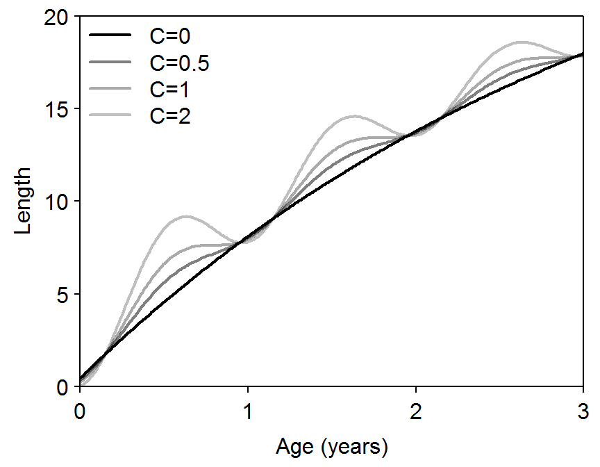

Figure 1: Example growth trajectory of Equation 1 using Equation 3 with $L_{\infty}$=30, $K$=0.3, $t_{0}$=-0.05, $t_{s}$=0.3 (or $WP$=0.8), and four different values of $C$.

Values of $C$>1 (or <0) in Equation 3 allow seasonal decreases in mean length-at-age (Figure 1). A decrease in mean length is unlikely for organisms whose skeletons largely preclude shrinkage (Pauly et al. 1992), although a seasonal crease in mean length-at-age is possible if size-dependent overwinter mortality occurs (Garcia-Berthou et al. 2012). To address this issue, Pauly et al. (1992) modified Equation 3: to include a true seasonal no-growth period with a smooth transition of the modeled mean length-at-age into and out of the no-growth period. Specifically, their modification is

$$\begin{aligned}
q & =K^{'}(t^{'}-t_{0}) \\
& +\frac{K^{'}(1-NGT)}{2\pi}sin\left(\frac{2\pi}{1-NGT}(t^{'}-t_{s})\right) \quad \quad \quad \quad \text{(4)} \\
& -\frac{K^{'}(1-NGT)}{2\pi}sin\left(\frac{2\pi}{1-NGT}(t_{0}-t_{s})\right)
\end{aligned}$$

where $NGT$ is the “no-growth time” or the length of the no growth period (in fractions of a year) and $t^{'}$ is found by “subtracting from the real age ($t$) the total no-growth time occurring up to age $t$.” Furthermore, Pauly et al. (1992) introduced $K^{'}$ to Equation 4 because the units of $K$ change from $year^{-1}$ in Equation 3 to $(1-NGT)^{-1}$ in Equation 4 because $t^{'}$<$t$ for any $t$. We further note here that $K^{'}$>$K$ because annual growth is compressed into a shorter period ($1-NGT$) in Equation 4 when $NGT$>0.

Pauly et al. (1992) derived Equation 4 by assuming $C$=1 (i.e., that the rate of growth is 0 at one point, $WP$), replacing $2\pi$ with $\frac{2\pi}{1-NGT}$ (i.e., restricting the oscillation to the period of growth), and replacing $K$ with $K^{'}$. Furthermore, their modification can be described geometrically (though not algorithmically) in two steps. First, the seasonal growth function in Equation 3 with $C$=1 is fit to the observed lengths and ages that have had the cumulative $NGT$ subtracted (i.e., the $t^{'}$). The growth trajectory is then separated at the $WP$ and a horizontal segment that is $NGT$ units long is inserted. This forms a growth trajectory that smoothly transitions into and out of a no-growth period (Figure 2).

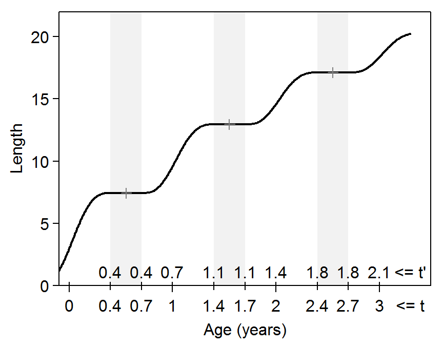

Figure 2: Example growth trajectory of Equation 1 using Equation 4 with $L_{\infty}$=30, $K^{'}$=0.4, $t_{0}$=-0.1, $t_{s}$=0.05, and $NGT$=0.3. Each no-growth period is marked by a light gray polygon and each $WP$ is marked by the gray plus symbol. The ages adjusted for the $NGT$ (i.e., $t^{'}$) are shown above the x-axis.

# The Modified Model

The $WP$ value is equal to $t_{s}+0.5$ because of the shape of the sin function used to model the oscillations. Thus, Equation 4 can be simply modified to include $WP$ rather than $t_{s}$ as

$$\begin{aligned}
q & =K^{'}(t^{'}-t_{0}) \\
& +\frac{K^{'}(1-NGT)}{2\pi}sin\left(\frac{2\pi}{1-NGT}(t^{'}-WP-0.5)\right) \quad \quad \quad \quad \text{(5)} \\
& -\frac{K^{'}(1-NGT)}{2\pi}sin\left(\frac{2\pi}{1-NGT}(t_{0}-WP-0.5)\right)
\end{aligned}$$

# Methods

## Simulated Data

## R Implementation

# Model Fitting

## Simulated Data

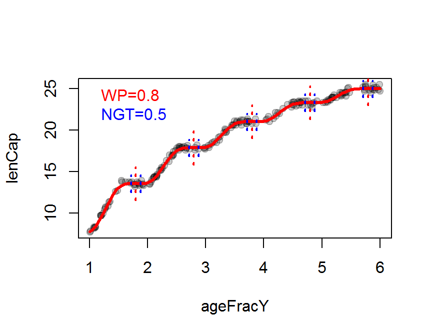

```
##             Est       2.5%      97.5%
## Linf 29.5417860 29.2284737 29.8734867
## K     0.3757916  0.3574196  0.3953120
## t0    0.2066148  0.1433948  0.2588665
## WP    0.7944574  0.7850181  0.8039542
## NGT   0.1637618  0.1209022  0.2052301
```

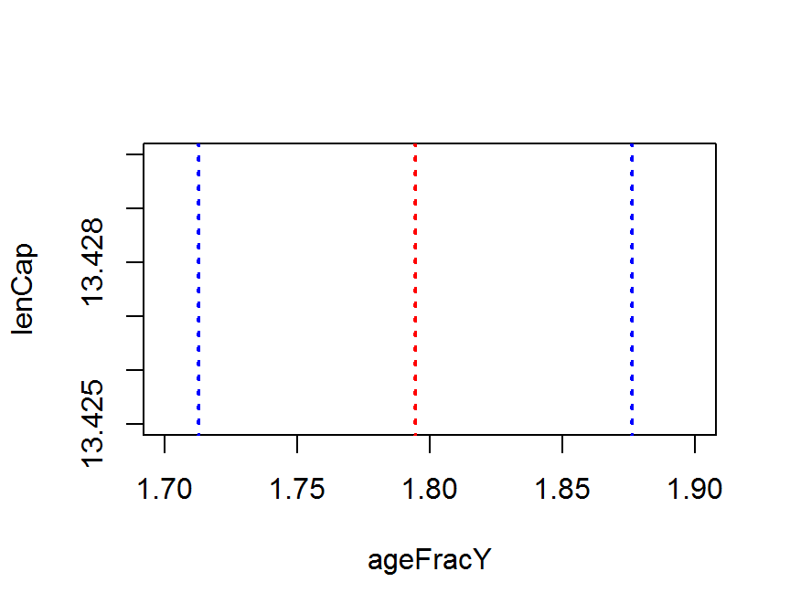

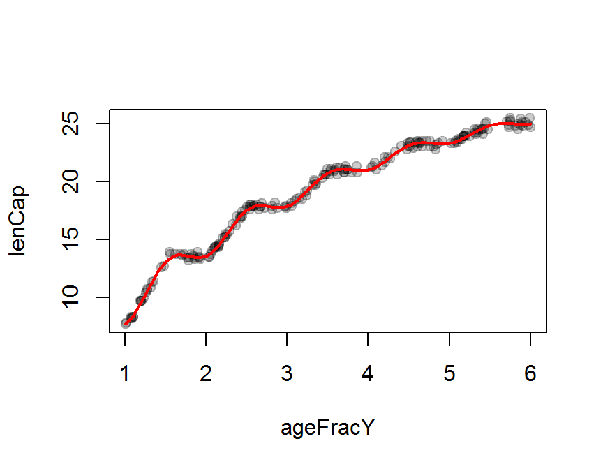

```
##                          2.5%       97.5%
## Linf 29.59794081 29.282403009 29.93253778
## K     0.31220330  0.302209706  0.32223856
## t0    0.04410893  0.002347852  0.07298911
## C     1.31396222  1.233845105  1.39465396
## WP    0.79426117  0.785196437  0.80338659
```

## Real Data

## Appendix

```r
################################################################################
## internal function to compute t-prime
##
################################################################################
iCalc_tpr <- function(t,WP,NGT) {
  ## First NGT stats at WP, use this to shift each age such that
  ##    first NGT would correspond to a value of 0
  tshift <- WP-NGT/2
  tmp.t <- t-tshift
  ## Find fraction of year on this new time scale for each adjusted age
  tmp.t2 <- tmp.t-floor(tmp.t)
  ## Adjust this fraction for no growth
  for (i in 1:length(tmp.t2)) {
    if (tmp.t2[i]<=NGT) tmp.t2[i] <- 0
    else tmp.t2[i] <- tmp.t2[i]-NGT
  }
  tmp.t <- floor(tmp.t)*(1-NGT)+tmp.t2
  ## Shift back to get tprime (why is NGT needed here)
  tpr <- tmp.t+tshift+NGT
}
```

```r
################################################################################
## Main Function
##
##   Linf, t0 as usual
##   Kpr = K-prime as defined in Pauly et al. (units are diff than usual K)
##   WP = "Winter Period" (point where growth=0) = ts+0.5 (ts from Pauly et al.)
##   NGT = "No Growth Time" = "fraction of a year where no growth occurs
##
##   tpr = "t-prime" = actual age (t) minus cumulative NGT prior to t
##   Q is as defined in Pauly et al.
##   qt and qtr are intermediate values to make Pauly SC look similar to the
##     Somers and Somers2 models from vbFuns() in FSA
##
##   The final line is basically Equation 4 from Pauly et al.
################################################################################

paulySC <- function(t,Linf,Kpr=NULL,t0=NULL,WP=NULL,NGT=NULL) {
  if (length(Linf)==5) { Kpr <- Linf[[2]]; t0 <- Linf[[3]]
                         WP <- Linf[[4]]; NGT <- Linf[[5]]
                         Linf <- Linf[[1]] }
  tpr <- iCalc_tpr(t,WP,NGT)
  Q <- (2*pi)/(1-NGT)
  qt <- (Kpr/Q)*sin(Q*(tpr-WP-0.5))
  qt0 <- (Kpr/Q)*sin(Q*(t0-WP-0.5))
  Linf*(1-exp(-Kpr*(tpr-t0)-qt+qt0))
}
```

Beverton, R. J. H., and S. J. Holt. 1957. On the dynamics of exploited fish populations. Page 533. United Kingdom Ministry of Agriculture; Fisheries.

Garcia-Berthou, E., G. Carmona-Catot, R. Merciai, and D. H. Ogle. 2012. A technical note on seasonal growth models. Reviews in Fish Biology and Fisheries 22:635–640.

Hoenig, N., and R. Choudaray Hanumara. 1982. A statistical study of a seasonal groWth model for fishes. Pages 32–34 Fishbyte. Tehcnical Report, Department of Computer Sciences; Statistics, University of Rhode Island.

Pauly, D., M. Soriano-Bartz, J. Moreau, and A. Jarre-Teichmann. 1992. A new model accounting for seasonal cessation of growth in fishes. Australian Journal of Marine and Freshwater Research 43:1151–1156.

Schnute, J., and D. Fournier. 1980. A new approach to length-frequency analysis: Growth structure. Canadian Journal of Fisheries and Aquatic Sciences 37:1337–1351.

Somers, I. F. 1988. On a seasonally oscillating growth function. Fishbyte 6(1):8–11.

von Bertalanffy, L. 1938. A quantitative theory of organic growth (inquiries on growth laws II). Human Biology 10:181–213.